# Human Taenia solium force-of-infection modelling project

Project to fit catalytic models to human Taenia solium age-(sero)prevalence data to estimate per-capita seroconversion / infection rates (force-of infection; FoI) and seroreversion / infection loss rates.

## Background

This project presents the first analysis to estimate these rates for T. solium human cysticercosis and human taeniasis, across a range of epidmeiological settings, after identifying suitable age-(sero)prevalence data from a systematic literature review. Cataltyic models are fitted using a bayesian framework, incorporating uncertainty in diagnostic performance (sensitivity and specificty of each test used) using the formula given by Diggle, (2011). Markov chain Monte Carlo (MCMC) simulations are used to estimate posterior distributions for parameters of interest (FoI, seroreversion/infection loss and diagnostic sensitvity and specificty). Our analysis therefore assesses global variation in these important epidemiological quantities to inform development of transmission models, and to support control efforts.

We provide code to support this analysis wtihin this repository.

Cataltyic models used to estimate rates in the paper are detailed in the following figure (full colour figure & parameter tables will become available after publication):

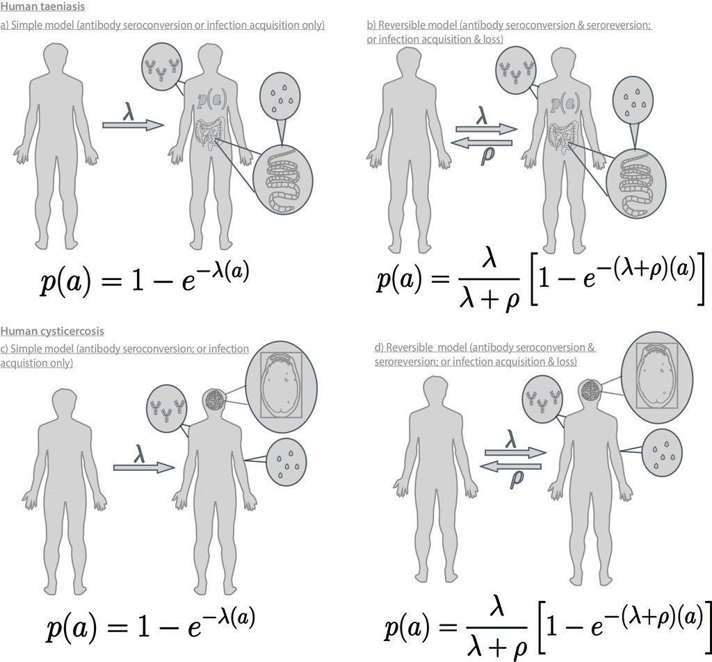

References:

Muench H (1943). Derivation of Rates from Summation Data by the Catalytic Curve. Journal of the American Statistics Association 29:25–38. doi: 10.2307/2278457. https://www.jstor.org/stable/2278457

Diggle P (2011). Estimating Prevalence Using an Imperfect Test. Epidemiology Research International. doi: 10.1155/2011/608719. https://www.hindawi.com/journals/eri/2011/608719/

## Code guide

The master script is split into: 1) fitting to single datasets 2) fitting to multiple datasets (this will estimate FoI/seroreversion or infection loss from each dataset, with a joint sensitivity and specifcity across datasets)

## Data availability

Data to support this study can be accessed through the following data repository at Imperial College London: https://data.hpc.imperial.ac.uk/resolve/?doi=10047

## Other related work

This is a complementary study to the pig cysticercosis FoI analysis conducted by this group and published in Scientific Reports:

[Dixon, M.A., Winskill, P., Harrison, W.E. et al. Force-of-infection of Taenia solium porcine cysticercosis: a modelling analysis to assess global incidence and prevalence trends. Sci Rep 10, 17637 (2020)](https://doi.org/10.1038/s41598-020-74007-x)

Together, these studies can be used to parameterise both the pig and human elements of a T. solium transmission model (where FoI estimates for pig and human infection exist for similar settings).